# HW4_IS457_33

# Do not remove any of the comments. These are marked by

# HW 4 - Due Monday, Oct 8, 2018 in moodle and hardcopy in class

# (1). Please upload R code and report to Moodle

# with filename: HW4_IS457_YourClassID.

# (2). Turn in hard copy of your report in class

# without your name but only your class ID

## Important: Make sure there is no identifying information on your printout, including name, username etc.

## Only include your class ID on there.

### ClassID: 33

# In this assignment you will practice linear regression in R

# Part 1. Linear Regression Concepts (6pts)

## These questions do not require coding but you will need to explain the details.

## In this homework, “Regression” refers to the simple linear regression equation: y = b0 + b1*x

# Q1. (2pts)

# What is the interpretation of the coefficient b1? (What meaning does it represent?)

```r
#Your Answer: The coeffcient b1 represents the slope of the line of the linear regression.
```

# Q2. (2pts)

## Outliers are problems for many statistical methods, but are particularly problematic for linear regression. Why is that? It may help to define what outlier means in this case.

## (Hint: Think of how residuals are calculated)

```r
#Your Answer: An outlier is a point of the data that can be defined as an extreme- or more than a few standard deviations
#from the mean. This can have a signficant effect on a linear regression by changing either coefficient in a way that does
#not accurately model the remained of your data.
```

# Q3. (2pts)

## How could you deal with outliers in order to improve the accuracy of your model?

```r
#Your Answer: One should be careful before removing outliers. Outliers can be the result of improper data or measurement errors,
#or they can be extreme versions of the results. However, if we are looking toward getting the best fitting linear model,
#the outlier can be removed.
```

# Part 2. Sampling, Point Estimation, and creating functions

# The following problems will use the Rabbit dataset and

# explore the Blood Pressure change(BPchange) for Rabbit in control group of “Treatment”.

# Load the data by running the following code:

```r
library(MASS)
data(Rabbit)
```

# Q4.

# Subset the data frame to include ONLY rabbits (observations) in control group of “Treatment”. (2pts)

# Name it ‘rabbitCon’, and show the first 10 observations of your output.(2pts)

### Your code:

```r
rabbitCon <- Rabbit[Rabbit$Treatment == "Control",]
head(rabbitCon, n=10)
```

```
##    BPchange   Dose Run Treatment Animal
## 1      0.50   6.25  C1   Control     R1
## 2      4.50  12.50  C1   Control     R1
## 3     10.00  25.00  C1   Control     R1
## 4     26.00  50.00  C1   Control     R1
## 5     37.00 100.00  C1   Control     R1
## 6     32.00 200.00  C1   Control     R1
## 7      1.00   6.25  C2   Control     R2
## 8      1.25  12.50  C2   Control     R2
## 9      4.00  25.00  C2   Control     R2
## 10    12.00  50.00  C2   Control     R2
```

# Use the sample function to generate a vector of 1s and 2s with the same length as rabbitCon, call it ‘group’.(2pts)

# Use this vector to split the ‘BPchange’ variable into two vectors, BP_V1 and BP_V2. (4pts)

# Print out the vectors group, BP_V1, BP_V2 and the lengths of BP_V1 and BP_V2.

# IMPORTANT: Make sure to run the seed function before running the sample function to ensure

# the result is reproducible.

```r
set.seed(457)  # DO NOT change
```

# Your Code:

```r
group <- sample(c(1,2), 30, replace=TRUE)
BP_list <- split(rabbitCon$BPchange, group)
BP_V1 <- BP_list[[1]]
BP_V2 <- BP_list[[2]]
group
```

```
##  [1] 1 1 1 2 2 1 1 2 1 2 2 2 2 1 1 1 2 2 1 1 1 1 2 1 1 1 2 1 1 2
```

```r
BP_V1
```

```
##  [1]  0.50  4.50 10.00 32.00  1.00  4.00  3.00  3.00 14.00  1.25  1.50
## [12]  6.00 19.00 33.00  1.50  1.50 16.00 20.00
```

```r
BP_V2
```

```
##  [1] 26.00 37.00  1.25 12.00 27.00 29.00  0.75 22.00 24.00 33.00  5.00
## [12] 18.00
```

```r
length(BP_V1)
```

```
## [1] 18
```

```r
length(BP_V2)
```

```
## [1] 12
```

# Q5(1)

# Calculate the mean and the standard deviation for each of the two vectors, BP_V1 and BP_V2. (4pts)

# Create a 95% confidence interval for your sample means using Z score.(4pts)

# (you can use the following formula for the Confidence Interval: mean +/- 2 * standard deviation).

# Compare the confidence intervals, do they seem to agree or disagree, explain (their ranges? differences?). (2pts)

# Your code:

```r
mBP_V1 <- mean(BP_V1)
mBP_V1
```

```
## [1] 9.541667
```

```r
sdBP_V1 <- sd(BP_V1)
sdBP_V1
```

```
## [1] 10.53574
```

```r
mBP_V2 <- mean(BP_V2)
mBP_V2
```

```
## [1] 19.58333
```

```r
sdBP_V2 <- sd(BP_V2)
sdBP_V2
```

```
## [1] 12.27355
```

```r
mBP_V1-1.96*sdBP_V1/sqrt(18)
```

```
## [1] 4.674403
```

```r
mBP_V1+1.96*sdBP_V1/sqrt(18)
```

```
## [1] 14.40893
```

```r
mBP_V2-1.96*sdBP_V2/sqrt(18)
```

```
## [1] 13.91324
```

```r
mBP_V2+1.96*sdBP_V2/sqrt(18)
```

```
## [1] 25.25343
```

```r
#I would say that the confidence intervals do not agree. Their differences are about the same, being off by about two. However, the ranges are not similar, and there is very little overlap. The overlap is less than 0.5.
```

# Note: the z score for 95% confidence interval is 1.96.

# Q5(2) From what you practice in 5 (1), let’s generalize the calculation process. (5pts)

# Write a function to calculate the 95% confidence intervals of any input vector (numerical) x, according

# to the formula given in the previous question.

```r
confidence_interval_.95 <- function(x) {
  low <- mean(x)-1.96*sd(x)/sqrt(length(x))
  up <- mean(x)+1.96*sd(x)/sqrt(length(x))
  return(list(low,up))
}
confidence_interval_.95(BP_V1)
```

```
## [[1]]
## [1] 4.674403
##
## [[2]]
## [1] 14.40893
```

```r
confidence_interval_.95(BP_V2)
```

```
## [[1]]
## [1] 12.63892
##
## [[2]]
## [1] 26.52775
```

# Q6.

# Using the hist() fucntion, plot a histogram of BPchange of rabbits under control group as well as for

# the MDL group (separately). (2pts)

# Do the histograms resemble a normal distribution? why or why not? (2pts)

# Comment on the shape of the distributions you see in the histgrams. What does the shape indicate in the

# context of this dataset?(4pts)

# Your Code:

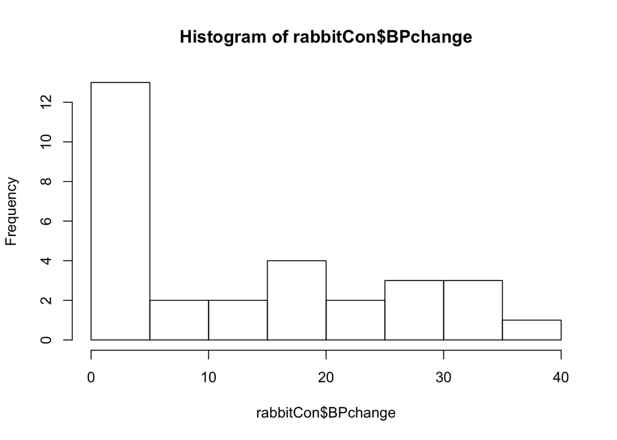

```r
rabbitMDL <- Rabbit[Rabbit$Treatment == "MDL",]
hist(rabbitCon$BPchange)
```

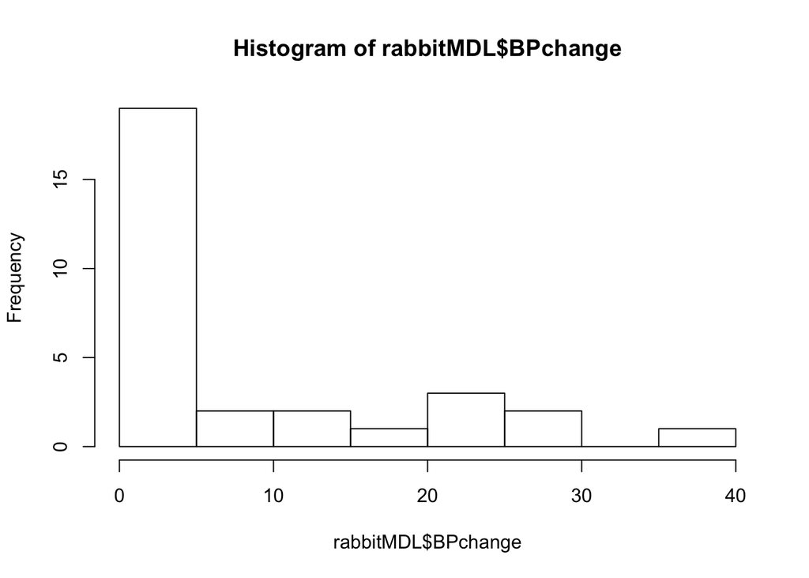

```r
hist(rabbitMDL$BPchange)
```

```r
#Neither of these histograms represent a normal distribution, as the data is not centered neatly around the mean.
#These histograms indicate higher number cases of low BPchange, meaning that the mode would be significantly lower
#than the mean.
```

# Part 3 Linear Regression

# This problem will use the same dataset as Part 2.

# We will focus on two variables:

# BP change: change in blood pressure relative to the start of the experiment.

# Dose: dose of Phenylbiguanide in micrograms.

# To start with, let us define a null hypthosesis. If we want to test the effect of dosage on BPchange,

# the null hypthosesis is:

# H0: Dosage has no effect on BPchange.

# H0: B1 = 0

# HA: B1 != 0

# Q7.

# Fit a linear regresssion using Dose to predict BPchange, using lm() for rabbits under MDL treatment. (2pts)

# Name it ‘model_BP’. What function would you use to get the summary statistics from lm models? Go ahead and use it. (2pts)

# Examine the model diagnostics using plot().

# Comment on the plots, what do the fitted values, noise, outliers look like?(8pts)

# Would you consider this a good model or not? Please explain. (2pts)

# Your code:

```r
model_BP <- lm(BPchange ~ Dose, data = rabbitMDL)
summary(model_BP)
```

```
##
## Call:
## lm(formula = BPchange ~ Dose, data = rabbitMDL)
##
## Residuals:
##     Min      1Q  Median      3Q     Max
## -8.2802 -2.3063 -0.1561  0.8526 12.4142
##
## Coefficients:
##             Estimate Std. Error t value Pr(>|t|)
## (Intercept) -0.10861    1.17505  -0.092    0.927
## Dose         0.13694    0.01246  10.986 1.16e-11 ***
## ---
## Signif. codes:  0 '***' 0.001 '**' 0.01 '*' 0.05 '.' 0.1 ' ' 1
##
## Residual standard error: 4.62 on 28 degrees of freedom
## Multiple R-squared:  0.8117, Adjusted R-squared:  0.805
## F-statistic: 120.7 on 1 and 28 DF,  p-value: 1.159e-11
```

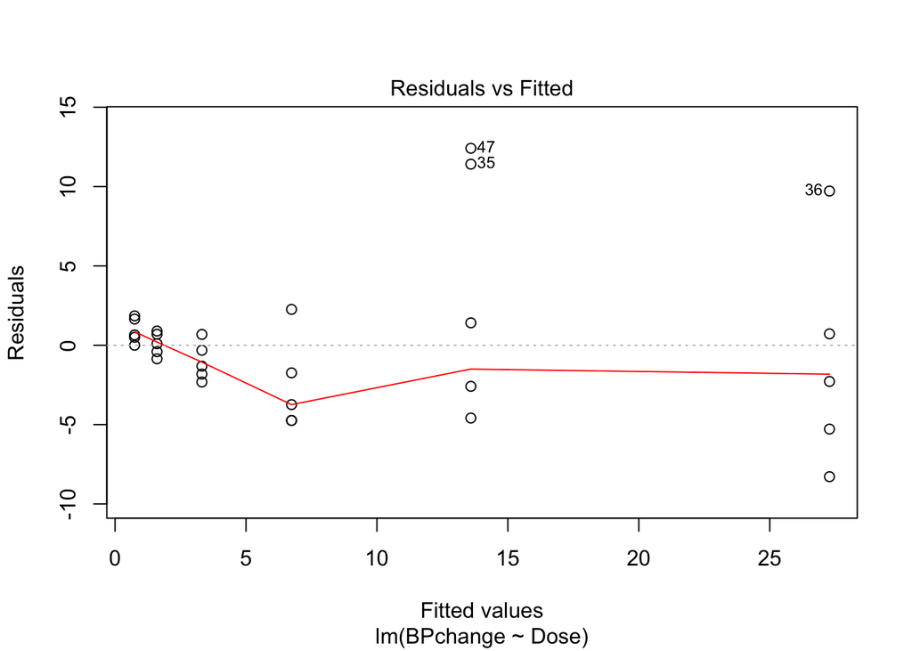

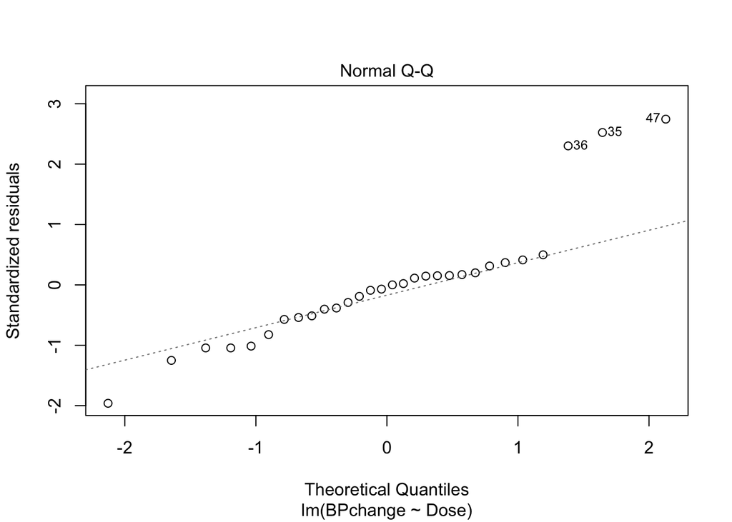

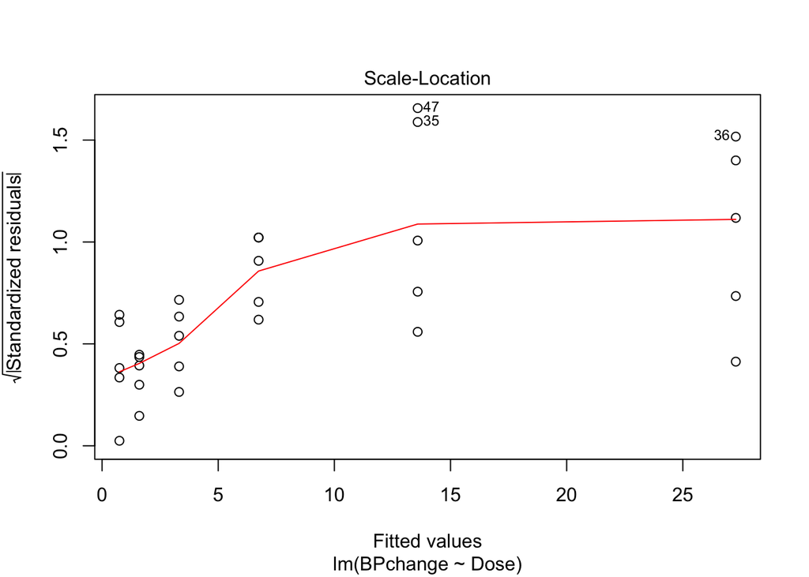

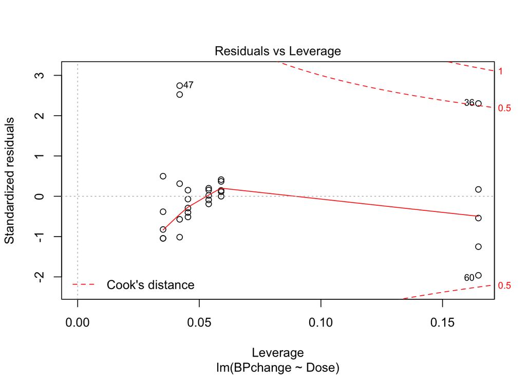

```r
plot(model_BP)
```

```r
#I would say this is a decent model based on the summary statistics. The p-value shows that there is a significant relationship
#at P<0.001. The R-Squared value is decent, but not very high (~0.81). There are a few outliers, and the fitted points show some random noise, but they are not significant enough to completely throw the model off course. However, they do have the effect of making the model not as strong as it could be.
```

# Q8.

# With the summary statistics from above, calculate the 95% confidence interval for Dose using t score (2pts)

# Note: use this code to find the t score: tvalue <- qt(1-0.05/2,nrow(rabbitMDL)-2)

# Your Code:

```r
tvalue <- qt(1-0.05/2,nrow(rabbitMDL)-1.96)
mean(rabbitMDL$Dose)-tvalue*sd(rabbitMDL$Dose)/sqrt(length(rabbitMDL$Dose))
```

```
## [1] 39.88398
```

```r
mean(rabbitMDL$Dose)+tvalue*sd(rabbitMDL$Dose)/sqrt(length(rabbitMDL$Dose))
```

```
## [1] 91.36602
```

# Q9.

# Based on the result from Q7& Q8 (p-value and CI), would you reject the null hypothesis or not? Explain. (2pts)

# Your Answer: I would rejject the null hypothesis due to a very low p-value and the confidence interval which

# places the mean in a reasonable expected place. This would mean that there is some relationship between dose and BP_change.